# Assignment #2

20141831 박석환

### import data

자료 가져오기

```r
cb <- read.csv("CommonBank.csv")
str(cb)
```

```
## 'data.frame':    5000 obs. of  14 variables:
##  $ ID               : int  1 2 3 4 5 6 7 8 9 10 ...
##  $ Age              : int  25 45 39 35 35 37 53 50 35 34 ...
##  $ Experience       : int  1 19 15 9 8 13 27 24 10 9 ...
##  $ Income           : int  49 34 11 100 45 29 72 22 81 180 ...
##  $ ZIP.Code         : int  91107 90089 94720 94112 91330 92121 91711 93943 90089 93023 ...
##  $ Family           : int  4 3 1 1 4 4 2 1 3 1 ...
##  $ CCAvg            : num  1.6 1.5 1 2.7 1 0.4 1.5 0.3 0.6 8.9 ...
##  $ Education        : int  1 1 1 2 2 2 2 3 2 3 ...
##  $ Mortgage         : int  0 0 0 0 0 155 0 0 104 0 ...
##  $ PersonalLoan     : int  0 0 0 0 0 0 0 0 0 1 ...
##  $ SecuritiesAccount: int  1 1 0 0 0 0 0 0 0 0 ...
##  $ CDAccount        : int  0 0 0 0 0 0 0 0 0 0 ...
##  $ Online           : int  0 0 0 0 0 1 1 0 1 0 ...
##  $ CreditCard       : int  0 0 0 0 1 0 0 1 0 0 ...
```

### 데이터 전처리

범주형 데이터 factorize

```r
cb$PersonalLoan <- factor(cb$PersonalLoan, levels = c("0","1"), labels = c("Reject","Accept"))
```

training set과 test set으로 나누기

```r
cb_train <- cb[1:4000,]
cb_test <- cb[4001:5000, ]
str(cb_train)
```

```
## 'data.frame':    4000 obs. of  14 variables:
##  $ ID               : int  1 2 3 4 5 6 7 8 9 10 ...
##  $ Age              : int  25 45 39 35 35 37 53 50 35 34 ...
##  $ Experience       : int  1 19 15 9 8 13 27 24 10 9 ...
##  $ Income           : int  49 34 11 100 45 29 72 22 81 180 ...
##  $ ZIP.Code         : int  91107 90089 94720 94112 91330 92121 91711 93943 90089 93023 ...
##  $ Family           : int  4 3 1 1 4 4 2 1 3 1 ...
##  $ CCAvg            : num  1.6 1.5 1 2.7 1 0.4 1.5 0.3 0.6 8.9 ...
##  $ Education        : int  1 1 1 2 2 2 2 3 2 3 ...
##  $ Mortgage         : int  0 0 0 0 0 155 0 0 104 0 ...
##  $ PersonalLoan     : Factor w/ 2 levels "Reject","Accept": 1 1 1 1 1 1 1 1 1 2 ...
##  $ SecuritiesAccount: int  1 1 0 0 0 0 0 0 0 0 ...
##  $ CDAccount        : int  0 0 0 0 0 0 0 0 0 0 ...
##  $ Online           : int  0 0 0 0 0 1 1 0 1 0 ...
##  $ CreditCard       : int  0 0 0 0 1 0 0 1 0 0 ...
```

```r
str(cb_test)
```

```
## 'data.frame':    1000 obs. of  14 variables:
##  $ ID               : int  4001 4002 4003 4004 4005 4006 4007 4008 4009 4010 ...
##  $ Age              : int  62 61 59 47 65 56 56 31 61 42 ...
##  $ Experience       : int  37 35 34 21 39 32 32 7 31 18 ...
##  $ Income           : int  93 81 60 39 22 32 28 35 154 189 ...
##  $ ZIP.Code         : int  93003 94709 94015 92612 92507 95827 92130 91745 94555 91605 ...
##  $ Family           : int  3 4 2 3 3 2 1 2 3 2 ...
##  $ CCAvg            : num  3 1.9 2.8 0.6 0.7 0.8 1.2 1 7.5 7.6 ...
##  $ Education        : int  3 2 1 2 2 1 3 2 3 1 ...
##  $ Mortgage         : int  0 0 0 0 0 79 0 0 351 0 ...
##  $ PersonalLoan     : Factor w/ 2 levels "Reject","Accept": 2 1 1 1 1 1 1 1 2 1 ...
##  $ SecuritiesAccount: int  0 0 0 0 0 1 0 0 0 0 ...
##  $ CDAccount        : int  1 0 0 0 0 0 0 0 1 0 ...
##  $ Online           : int  1 0 1 1 0 1 1 0 1 1 ...
##  $ CreditCard       : int  1 0 0 1 0 0 0 1 1 0 ...
```

### assignment 2-1

**첫 4000명의 데이터를 training set으로, 나머지 1000명의 데이터를 test set으로 사용하자. Training set과 test set에서의 PersonalLoan 값의 분포를 비교해 보자.**

### 조건에 맞게 데이터 전처리

필요한 PersonalLoan 열에 대한 데이터만 추출

```r
cb_train_loan <- as.data.frame(cb_train$PersonalLoan)
cb_test_loan <- as.data.frame(cb_test$PersonalLoan)
str(cb_train_loan)
```

```
## 'data.frame':    4000 obs. of  1 variable:
##  $ cb_train$PersonalLoan: Factor w/ 2 levels "Reject","Accept": 1 1 1 1 1 1 1 1 1 2 ...
```

```r
str(cb_test_loan)
```

```
## 'data.frame':    1000 obs. of  1 variable:
##  $ cb_test$PersonalLoan: Factor w/ 2 levels "Reject","Accept": 2 1 1 1 1 1 1 1 2 1 ...
```

각 data set 지정 후 컬럼명 변경

```r
library(dplyr)
cb_train_loan <- cb_train_loan %>% mutate(data = "train")
cb_test_loan <- cb_test_loan %>% mutate(data = "test")
names(cb_train_loan)[1] <- "PersonalLoan"
names(cb_test_loan)[1] <- "PersonalLoan"
str(cb_train_loan)
```

```
## 'data.frame':    4000 obs. of  2 variables:
##  $ PersonalLoan: Factor w/ 2 levels "Reject","Accept": 1 1 1 1 1 1 1 1 1 2 ...
##  $ data        : chr  "train" "train" "train" "train" ...
```

```r
str(cb_test_loan)
```

```
## 'data.frame':    1000 obs. of  2 variables:
##  $ PersonalLoan: Factor w/ 2 levels "Reject","Accept": 2 1 1 1 1 1 1 1 2 1 ...
##  $ data        : chr  "test" "test" "test" "test" ...
```

value를 대입시켜 각 인원수 파악

```r
data_loan <-rbind(cb_train_loan, cb_test_loan)
data_loan <- data_loan %>% mutate(value = 1)

library(reshape2)
data_loan <- dcast(data_loan, data + PersonalLoan ~ value, fun = sum)
names(data_loan)[3] <- "value"
str(data_loan)
```

```
## 'data.frame':    4 obs. of  3 variables:
##  $ data        : chr  "test" "test" "train" "train"
##  $ PersonalLoan: Factor w/ 2 levels "Reject","Accept": 1 2 1 2
##  $ value       : num  917 83 3603 397
```

퍼센트 구하기

```r
data_loan <- data_loan %>%
  group_by(data) %>%
  mutate(percent = (value / sum(value))*100)
```

```r
data_loan$value<-paste(data_loan$value,"명")
data_loan
```

```
## # A tibble: 4 x 4
## # Groups:   data [2]
##   data  PersonalLoan value   percent
##   <chr> <fct>        <chr>     <dbl>
## 1 test  Reject       917 명    91.7
## 2 test  Accept       83 명      8.3
## 3 train Reject       3603 명   90.1
## 4 train Accept       397 명     9.93
```

그래프로 시각화

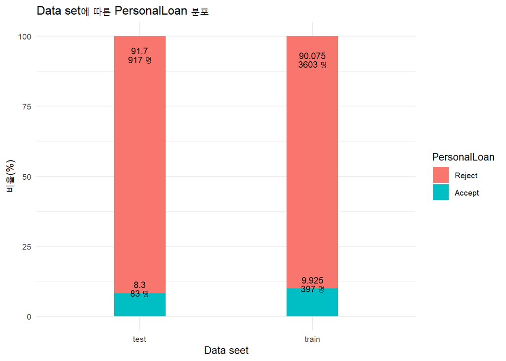

```r
library(ggplot2)
ggplot(data_loan, aes(x=data, y=percent, fill = PersonalLoan)) +  geom_bar(stat = "identity", width = 0.3) +
  theme_minimal() + theme(text = element_text(size = 10)) +
  geom_text(aes(label=percent),vjust = -0.8, size=3,  color = 'black') +
  geom_text(aes(label=value),  size=3,  color = 'black') +
  labs(title = "Data set에 따른 PersonalLoan 분포", x = "Data seet", y = "비율(%)" )
```

## assignment 2-2

**7-NN을 적용해 보자. 이때 ID와 ZIP.code는 feature에서 제외한다.**

조건에 맞게 데이터 분류하기

```r
cb$PersonalLoan <- as.character(cb$PersonalLoan)
cb_data <- cb[-c(1, 5)]
str(cb_data)
```

```
## 'data.frame':    5000 obs. of  12 variables:
##  $ Age              : int  25 45 39 35 35 37 53 50 35 34 ...
##  $ Experience       : int  1 19 15 9 8 13 27 24 10 9 ...
##  $ Income           : int  49 34 11 100 45 29 72 22 81 180 ...
##  $ Family           : int  4 3 1 1 4 4 2 1 3 1 ...
##  $ CCAvg            : num  1.6 1.5 1 2.7 1 0.4 1.5 0.3 0.6 8.9 ...
##  $ Education        : int  1 1 1 2 2 2 2 3 2 3 ...
##  $ Mortgage         : int  0 0 0 0 0 155 0 0 104 0 ...
##  $ PersonalLoan     : chr  "Reject" "Reject" "Reject" "Reject" ...
##  $ SecuritiesAccount: int  1 1 0 0 0 0 0 0 0 0 ...
##  $ CDAccount        : int  0 0 0 0 0 0 0 0 0 0 ...
##  $ Online           : int  0 0 0 0 0 1 1 0 1 0 ...
##  $ CreditCard       : int  0 0 0 0 1 0 0 1 0 0 ...
```

연속형 데이터 nomalize

```r
normalize<-function(x) {
  return ((x-min(x))/(max(x)-min(x)))
}
```

```r
cb_n <- as.data.frame(lapply(cb_data[c(1,2,3,4,5,7)], normalize))
str(cb_n)
```

```
## 'data.frame':    5000 obs. of  6 variables:
##  $ Age       : num  0.0455 0.5 0.3636 0.2727 0.2727 ...
##  $ Experience: num  0.087 0.478 0.391 0.261 0.239 ...
##  $ Income    : num  0.1898 0.1204 0.0139 0.4259 0.1713 ...
##  $ Family    : num  1 0.667 0 0 1 ...
##  $ CCAvg     : num  0.16 0.15 0.1 0.27 0.1 0.04 0.15 0.03 0.06 0.89 ...
##  $ Mortgage  : num  0 0 0 0 0 ...
```

범주형 데이터 합쳐주기

```r
cb_normalized <- cbind(cb_n, cb_data[c(6,9,10,11,12)])
str(cb_normalized)
```

```
## 'data.frame':    5000 obs. of  11 variables:
##  $ Age              : num  0.0455 0.5 0.3636 0.2727 0.2727 ...
##  $ Experience       : num  0.087 0.478 0.391 0.261 0.239 ...
##  $ Income           : num  0.1898 0.1204 0.0139 0.4259 0.1713 ...
##  $ Family           : num  1 0.667 0 0 1 ...
##  $ CCAvg            : num  0.16 0.15 0.1 0.27 0.1 0.04 0.15 0.03 0.06 0.89 ...
##  $ Mortgage         : num  0 0 0 0 0 ...
##  $ Education        : int  1 1 1 2 2 2 2 3 2 3 ...
##  $ SecuritiesAccount: int  1 1 0 0 0 0 0 0 0 0 ...
##  $ CDAccount        : int  0 0 0 0 0 0 0 0 0 0 ...
##  $ Online           : int  0 0 0 0 0 1 1 0 1 0 ...
##  $ CreditCard       : int  0 0 0 0 1 0 0 1 0 0 ...
```

training set과 test set으로 나누기

```r
cb_train_data <- cb_normalized[1:4000,]
cb_test_data <- cb_normalized[4001:5000,]
cb_train_label <- cb_data[1:4000, 8]
cb_test_label <- cb_data[4001:5000, 8]
```

knn 알고리즘 사용

```r
library(class)
cb_test_pred<-knn(train=cb_train_data, test=cb_test_data, cl= cb_train_label, k=7)
```

```r
library(gmodels)
CrossTable(x=cb_test_label, y=cb_test_pred, prop.chisq = FALSE)
```

```
##
##
##    Cell Contents
## |-------------------------|
## |                       N |
## |           N / Row Total |
## |           N / Col Total |
## |         N / Table Total |
## |-------------------------|
##
##
## Total Observations in Table:  1000
##
##
##               | cb_test_pred
## cb_test_label |    Accept |    Reject | Row Total |
## --------------|-----------|-----------|-----------|
##        Accept |        41 |        42 |        83 |
##               |     0.494 |     0.506 |     0.083 |
##               |     0.953 |     0.044 |           |
##               |     0.041 |     0.042 |           |
## --------------|-----------|-----------|-----------|
##        Reject |         2 |       915 |       917 |
##               |     0.002 |     0.998 |     0.917 |
##               |     0.047 |     0.956 |           |
##               |     0.002 |     0.915 |           |
## --------------|-----------|-----------|-----------|
##  Column Total |        43 |       957 |      1000 |
##               |     0.043 |     0.957 |           |
## --------------|-----------|-----------|-----------|
##
##
```

### assignment 2-3

**다양한 k 값에 대해 k-NN을 적용해 보고 test set에 대한 예측 성능을 비교해 보자. k가 어떤 값을 가질때 모델의 성능이 가장 우수한가?**

다양한 k값 설정(k=1,3,5,7,9,11,15,21,27)

```r
library(class)
cb_test_pred_1<-knn(train=cb_train_data, test=cb_test_data, cl= cb_train_label, k=1)
cb_test_pred_3<-knn(train=cb_train_data, test=cb_test_data, cl= cb_train_label, k=3)
cb_test_pred_5<-knn(train=cb_train_data, test=cb_test_data, cl= cb_train_label, k=5)
cb_test_pred_7<-knn(train=cb_train_data, test=cb_test_data, cl= cb_train_label, k=7)
cb_test_pred_9<-knn(train=cb_train_data, test=cb_test_data, cl= cb_train_label, k=9)
cb_test_pred_11<-knn(train=cb_train_data, test=cb_test_data, cl= cb_train_label, k=11)
cb_test_pred_15<-knn(train=cb_train_data, test=cb_test_data, cl= cb_train_label, k=15)
cb_test_pred_21<-knn(train=cb_train_data, test=cb_test_data, cl= cb_train_label, k=21)
cb_test_pred_27<-knn(train=cb_train_data, test=cb_test_data, cl= cb_train_label, k=27)
```

각 k값에 대한 그래프 결과

```r
library(gmodels)
Ctable1<-CrossTable(x=cb_test_label, y=cb_test_pred_1, prop.chisq = FALSE)
```

```
##
##
##    Cell Contents
## |-------------------------|
## |                       N |
## |           N / Row Total |
## |           N / Col Total |
## |         N / Table Total |
## |-------------------------|
##
##
## Total Observations in Table:  1000
##
##
##               | cb_test_pred_1
## cb_test_label |    Accept |    Reject | Row Total |
## --------------|-----------|-----------|-----------|
##        Accept |        60 |        23 |        83 |
##               |     0.723 |     0.277 |     0.083 |
##               |     0.857 |     0.025 |           |
##               |     0.060 |     0.023 |           |
## --------------|-----------|-----------|-----------|
##        Reject |        10 |       907 |       917 |
##               |     0.011 |     0.989 |     0.917 |
##               |     0.143 |     0.975 |           |
##               |     0.010 |     0.907 |           |
## --------------|-----------|-----------|-----------|
##  Column Total |        70 |       930 |      1000 |
##               |     0.070 |     0.930 |           |
## --------------|-----------|-----------|-----------|
##
##
```

```r
Ctable3<-CrossTable(x=cb_test_label, y=cb_test_pred_3, prop.chisq = FALSE)
```

```
##
##
##    Cell Contents
## |-------------------------|
## |                       N |
## |           N / Row Total |
## |           N / Col Total |
## |         N / Table Total |
## |-------------------------|
##
##
## Total Observations in Table:  1000
##
##
##               | cb_test_pred_3
## cb_test_label |    Accept |    Reject | Row Total |
## --------------|-----------|-----------|-----------|
##        Accept |        54 |        29 |        83 |
##               |     0.651 |     0.349 |     0.083 |
##               |     0.931 |     0.031 |           |
##               |     0.054 |     0.029 |           |
## --------------|-----------|-----------|-----------|
##        Reject |         4 |       913 |       917 |
##               |     0.004 |     0.996 |     0.917 |
##               |     0.069 |     0.969 |           |
##               |     0.004 |     0.913 |           |
## --------------|-----------|-----------|-----------|
##  Column Total |        58 |       942 |      1000 |
##               |     0.058 |     0.942 |           |
## --------------|-----------|-----------|-----------|
##
##
```

```r
Ctable5<-CrossTable(x=cb_test_label, y=cb_test_pred_5, prop.chisq = FALSE)
```

```
##
##
##    Cell Contents
## |-------------------------|
## |                       N |
## |           N / Row Total |
## |           N / Col Total |
## |         N / Table Total |
## |-------------------------|
##
##
## Total Observations in Table:  1000
##
##
##               | cb_test_pred_5
## cb_test_label |    Accept |    Reject | Row Total |
## --------------|-----------|-----------|-----------|
##        Accept |        46 |        37 |        83 |
##               |     0.554 |     0.446 |     0.083 |
##               |     0.958 |     0.039 |           |
##               |     0.046 |     0.037 |           |
## --------------|-----------|-----------|-----------|
##        Reject |         2 |       915 |       917 |
##               |     0.002 |     0.998 |     0.917 |
##               |     0.042 |     0.961 |           |
##               |     0.002 |     0.915 |           |
## --------------|-----------|-----------|-----------|
##  Column Total |        48 |       952 |      1000 |
##               |     0.048 |     0.952 |           |
## --------------|-----------|-----------|-----------|
##
##
```

```r
Ctable7<-CrossTable(x=cb_test_label, y=cb_test_pred_7, prop.chisq = FALSE)
```

```
##
##
##    Cell Contents
## |-------------------------|
## |                       N |
## |           N / Row Total |
## |           N / Col Total |
## |         N / Table Total |
## |-------------------------|
##
##
## Total Observations in Table:  1000
##
##
##               | cb_test_pred_7
## cb_test_label |    Accept |    Reject | Row Total |
## --------------|-----------|-----------|-----------|
##        Accept |        41 |        42 |        83 |
##               |     0.494 |     0.506 |     0.083 |
##               |     0.953 |     0.044 |           |
##               |     0.041 |     0.042 |           |
## --------------|-----------|-----------|-----------|
##        Reject |         2 |       915 |       917 |
##               |     0.002 |     0.998 |     0.917 |
##               |     0.047 |     0.956 |           |
##               |     0.002 |     0.915 |           |
## --------------|-----------|-----------|-----------|
##  Column Total |        43 |       957 |      1000 |
##               |     0.043 |     0.957 |           |
## --------------|-----------|-----------|-----------|
##
##
```

```r
Ctable9<-CrossTable(x=cb_test_label, y=cb_test_pred_9, prop.chisq = FALSE)
```

```
##
##
##    Cell Contents
## |-------------------------|
## |                       N |
## |           N / Row Total |
## |           N / Col Total |
## |         N / Table Total |
## |-------------------------|
##
##
## Total Observations in Table:  1000
##
##
##               | cb_test_pred_9
## cb_test_label |    Accept |    Reject | Row Total |
## --------------|-----------|-----------|-----------|
##        Accept |        41 |        42 |        83 |
##               |     0.494 |     0.506 |     0.083 |
##               |     0.953 |     0.044 |           |
##               |     0.041 |     0.042 |           |
## --------------|-----------|-----------|-----------|
##        Reject |         2 |       915 |       917 |
##               |     0.002 |     0.998 |     0.917 |
##               |     0.047 |     0.956 |           |
##               |     0.002 |     0.915 |           |
## --------------|-----------|-----------|-----------|
##  Column Total |        43 |       957 |      1000 |
##               |     0.043 |     0.957 |           |
## --------------|-----------|-----------|-----------|
##
##
```

```r
Ctable11<-CrossTable(x=cb_test_label, y=cb_test_pred_11, prop.chisq = FALSE)
```

```
##
##
##    Cell Contents
## |-------------------------|
## |                       N |
## |           N / Row Total |
## |           N / Col Total |
## |         N / Table Total |
## |-------------------------|
##
##
## Total Observations in Table:  1000
##
##
##               | cb_test_pred_11
## cb_test_label |    Accept |    Reject | Row Total |
## --------------|-----------|-----------|-----------|
##        Accept |        36 |        47 |        83 |
##               |     0.434 |     0.566 |     0.083 |
##               |     0.947 |     0.049 |           |
##               |     0.036 |     0.047 |           |
## --------------|-----------|-----------|-----------|
##        Reject |         2 |       915 |       917 |
##               |     0.002 |     0.998 |     0.917 |
##               |     0.053 |     0.951 |           |
##               |     0.002 |     0.915 |           |
## --------------|-----------|-----------|-----------|
##  Column Total |        38 |       962 |      1000 |
##               |     0.038 |     0.962 |           |
## --------------|-----------|-----------|-----------|
##
##
```

```r
Ctable15<-CrossTable(x=cb_test_label, y=cb_test_pred_15, prop.chisq = FALSE)
```

```
##
##
##    Cell Contents
## |-------------------------|
## |                       N |
## |           N / Row Total |
## |           N / Col Total |
## |         N / Table Total |
## |-------------------------|
##
##
## Total Observations in Table:  1000
##
##
##               | cb_test_pred_15
## cb_test_label |    Accept |    Reject | Row Total |
## --------------|-----------|-----------|-----------|
##        Accept |        32 |        51 |        83 |
##               |     0.386 |     0.614 |     0.083 |
##               |     0.970 |     0.053 |           |
##               |     0.032 |     0.051 |           |
## --------------|-----------|-----------|-----------|
##        Reject |         1 |       916 |       917 |
##               |     0.001 |     0.999 |     0.917 |
##               |     0.030 |     0.947 |           |
##               |     0.001 |     0.916 |           |
## --------------|-----------|-----------|-----------|
##  Column Total |        33 |       967 |      1000 |
##               |     0.033 |     0.967 |           |
## --------------|-----------|-----------|-----------|
##
##
```

```r
Ctable21<-CrossTable(x=cb_test_label, y=cb_test_pred_21, prop.chisq = FALSE)
```

```
##
##
##    Cell Contents
## |-------------------------|
## |                       N |
## |           N / Row Total |
## |           N / Col Total |
## |         N / Table Total |
## |-------------------------|
##
##
## Total Observations in Table:  1000
##
##
##               | cb_test_pred_21
## cb_test_label |    Accept |    Reject | Row Total |
## --------------|-----------|-----------|-----------|
##        Accept |        27 |        56 |        83 |
##               |     0.325 |     0.675 |     0.083 |
##               |     0.900 |     0.058 |           |
##               |     0.027 |     0.056 |           |
## --------------|-----------|-----------|-----------|
##        Reject |         3 |       914 |       917 |
##               |     0.003 |     0.997 |     0.917 |
##               |     0.100 |     0.942 |           |
##               |     0.003 |     0.914 |           |
## --------------|-----------|-----------|-----------|
##  Column Total |        30 |       970 |      1000 |
##               |     0.030 |     0.970 |           |
## --------------|-----------|-----------|-----------|
##
##
```

```r
Ctable27<-CrossTable(x=cb_test_label, y=cb_test_pred_27, prop.chisq = FALSE)
```

```
##
##
##    Cell Contents
## |-------------------------|
## |                       N |
## |           N / Row Total |
## |           N / Col Total |
## |         N / Table Total |
## |-------------------------|
##
##
## Total Observations in Table:  1000
##
##
##               | cb_test_pred_27
## cb_test_label |    Accept |    Reject | Row Total |
## --------------|-----------|-----------|-----------|
##        Accept |        26 |        57 |        83 |
##               |     0.313 |     0.687 |     0.083 |
##               |     0.897 |     0.059 |           |
##               |     0.026 |     0.057 |           |
## --------------|-----------|-----------|-----------|
##        Reject |         3 |       914 |       917 |
##               |     0.003 |     0.997 |     0.917 |
##               |     0.103 |     0.941 |           |
##               |     0.003 |     0.914 |           |
## --------------|-----------|-----------|-----------|
##  Column Total |        29 |       971 |      1000 |
##               |     0.029 |     0.971 |           |
## --------------|-----------|-----------|-----------|
##
##
```

각 결과에 대한 accuracy 결과

```r
accuracy <- function(x) {
  return ((x$t[1]+x$t[4])/sum(x$t))
}
```

```r
a1 <- accuracy(Ctable1)
a3 <- accuracy(Ctable3)
a5 <-accuracy(Ctable5)
a7 <-accuracy(Ctable7)
a9 <-accuracy(Ctable9)
a11 <-accuracy(Ctable11)
a15 <-accuracy(Ctable15)
a21 <-accuracy(Ctable21)
a27 <-accuracy(Ctable27)
```

각 결과에 대한 sencitivity 값

```r
sensitive <- function(x) {
  return ((x$t[1]/(x$t[1]+x$t[3])))
}
s1<-sensitive(Ctable1)
s3<-sensitive(Ctable3)
s5<-sensitive(Ctable5)
s7<-sensitive(Ctable7)
s9<-sensitive(Ctable9)
s11<-sensitive(Ctable11)
s15<-sensitive(Ctable15)
s21<-sensitive(Ctable21)
s27<-sensitive(Ctable27)
```

데이터 프레임으로 만들기

```r
result <- data.frame(k=c(1,3,5,7,9,11,15,21,27), accuracy =c(a1,a3,a5,a7,a9,a11,a15,a21,a27),
                     sensitivity=c(s1,s3,s5,s7,s9,s11,s15,s21,s27))

result
```

```
##    k accuracy sensitivity
## 1  1    0.967   0.7228916
## 2  3    0.967   0.6506024
## 3  5    0.961   0.5542169
## 4  7    0.956   0.4939759
## 5  9    0.956   0.4939759
## 6 11    0.951   0.4337349
## 7 15    0.948   0.3855422
## 8 21    0.941   0.3253012
## 9 27    0.940   0.3132530
```

-> 1-NN 이 accuracy와 sensitivity가 모두 높으므로 가장 성능이 우수하다

### assignment 2-4

**Training set에 대해 5-fold cross validation을 5회 반복하여 best k 값을 찾아보자. best k 값으로 만들어지는 최종 model에 test set을 적용하여 model의 성능을 report하자**

###데이터 전처리 불러오기

```r
cb1 <- read.csv("CommonBank.csv")
cb1 <- cb1[-c(1, 5)]
str(cb1)
```

```
## 'data.frame':    5000 obs. of  12 variables:
##  $ Age              : int  25 45 39 35 35 37 53 50 35 34 ...
##  $ Experience       : int  1 19 15 9 8 13 27 24 10 9 ...
##  $ Income           : int  49 34 11 100 45 29 72 22 81 180 ...
##  $ Family           : int  4 3 1 1 4 4 2 1 3 1 ...
##  $ CCAvg            : num  1.6 1.5 1 2.7 1 0.4 1.5 0.3 0.6 8.9 ...
##  $ Education        : int  1 1 1 2 2 2 2 3 2 3 ...
##  $ Mortgage         : int  0 0 0 0 0 155 0 0 104 0 ...
##  $ PersonalLoan     : int  0 0 0 0 0 0 0 0 0 1 ...
##  $ SecuritiesAccount: int  1 1 0 0 0 0 0 0 0 0 ...
##  $ CDAccount        : int  0 0 0 0 0 0 0 0 0 0 ...
##  $ Online           : int  0 0 0 0 0 1 1 0 1 0 ...
##  $ CreditCard       : int  0 0 0 0 1 0 0 1 0 0 ...
```

범주형 데이터 factorize

```r
cb1$PersonalLoan <- factor(cb1$PersonalLoan, levels = c(0,1), labels = c("Reject", "Accept"))
```

training set, test set 설정

```r
cb_train_data1 <- cb1[1:4000,]
cb_test_data1 <- cb1[4001:5000,]
cb_train_label1 <- cb1[1:4000,8]
cb_test_label1 <- cb1[4001:5000,8]
```

### knn 모델 학습

train 함수의 parameter 설정

```r
library(caret)
z_normalized <- c("center", "scale")
tune_grid <- expand.grid(k=seq(1,99,2))
cv <- trainControl(method = "repeatedcv", number = 5, repeats = 5)
knn_fit <- train(data=cb_train_data1, PersonalLoan~., method = "knn", trControl = cv, preProcess = z_normalized, tuneGrid = tune_grid)
knn_fit
```

```
## k-Nearest Neighbors
##
## 4000 samples
##   11 predictor
##    2 classes: 'Reject', 'Accept'
##
## Pre-processing: centered (11), scaled (11)
## Resampling: Cross-Validated (5 fold, repeated 5 times)
## Summary of sample sizes: 3200, 3200, 3200, 3199, 3201, 3200, ...
## Resampling results across tuning parameters:
##
##   k   Accuracy   Kappa
##    1  0.9547008  0.7208878
##    3  0.9582499  0.7287791
##    5  0.9559498  0.7036692
```

[output cut: 50 more lines]

그래프 시각화

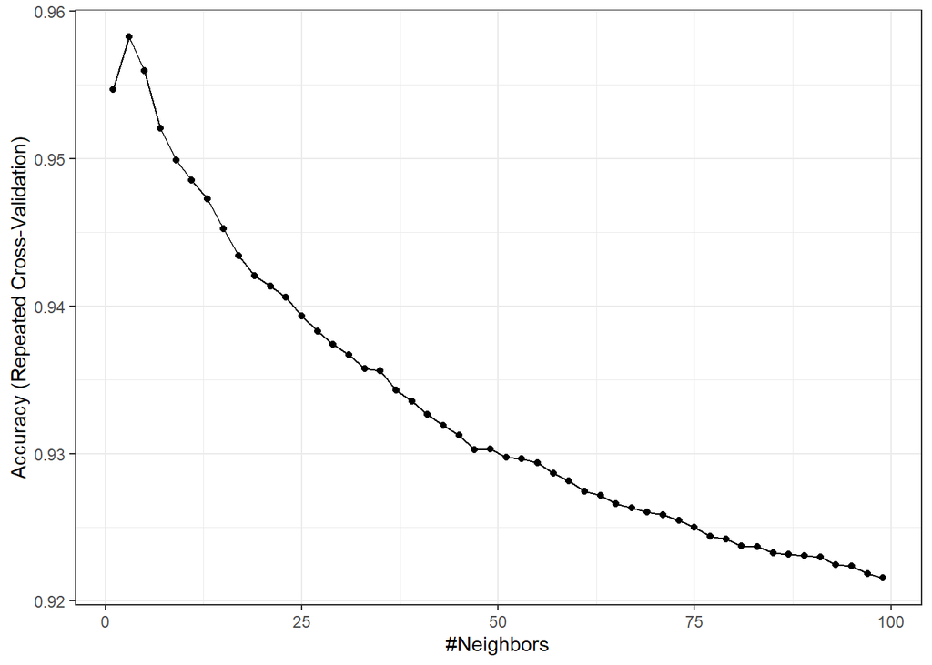

```r
library(ggplot2)
ggplot(knn_fit) + theme_bw()
```

extraPrediction 함수를 사용하여 최종 model을 test set에 적용하여 prediction error 계산

```r
knn_pred <- extractPrediction(list(knn_fit), testX = cb_test_data1[,-8], testY=cb_test_label1)
test_pred <- knn_pred$pred[knn_pred$dataType == "Test"]
test_obs <- knn_pred$obs[knn_pred$dataType == "Test"]
confusionMatrix(test_pred, test_obs, positive = "Accept")
```

```
## Confusion Matrix and Statistics
##
##           Reference
## Prediction Reject Accept
##     Reject    913     29
##     Accept      4     54
##
##                Accuracy : 0.967
##                  95% CI : (0.954, 0.9772)
##     No Information Rate : 0.917
##     P-Value [Acc > NIR] : 9.350e-11
##
##                   Kappa : 0.7488
##
##  Mcnemar's Test P-Value : 2.943e-05
##
##             Sensitivity : 0.6506
##             Specificity : 0.9956
##          Pos Pred Value : 0.9310
##          Neg Pred Value : 0.9692
##              Prevalence : 0.0830
##          Detection Rate : 0.0540
##    Detection Prevalence : 0.0580
##       Balanced Accuracy : 0.8231
##
##        'Positive' Class : Accept
##
```

### assignment 2-5

**3번과 4번의 training 방식의 장단점을 비교해보자**

*3번 방식*

간단하고 빠르기 때문에 k의 수가 적을때 사용하기 용이하다. 하지만 결과를 보고 비교를 하기 위한 수치를 직접 계산해야한다.

*4번 방식*

4번의 방식은 반복 검증이 가능하고, 한 번에 많은 수의 k를 비교 할 수있다. 또한, k값에 대한 여러 결과가 계산 되어서 출력되기 때문에 모델을 검증하기 용이하다. 하지만 자료가 많을 경우 데이터 처리 속도가 느려진다.